# Description

- making a sliding window GC distribution around the 16S rRNA gene

**Genome dataset:**

- just 1 member of each species
- using all genomes with amplicons generated from GRINDER run
- using ssu genes identified by rnammer

# Bacteria

- 1091 of 1162 bacterial genomes

**filtering reads**

- just need 1 amplicon from each 16S gene copy in each genome

@ system76-server:~/notebook/deltaGC_notes/data/amplicon/140331_allBac/amp454-L215-N1k/GC_dist

```
screen -S read_filter -L bash -c "grinder_readFilter.pl -r ../amp454-L215-N1k_reads.fa > amp454-L215-N1k_reads_filt.fa"

    * overlap window = 100bp

Number of reads pre-filtering: 1091000
Number remaining post-filtering: 4105
```

**getting GC distribution (sliding window)**

@ system76-server:~/notebook/deltaGC_notes/data/amplicon/140331_allBac/amp454-L215-N1k/GC_dist

```
screen -S GC_dist -L bash -c "GC_dist.pl -r amp454-L215-N1k_reads_filt.fa -g ../../prokBac-CompRep.fna -a -t 12 > prokBac-CompRep_16S_GC-byWindow.txt"
    * took ~1 min
```

## Making plots of GC distribution

```python
%load_ext rmagic
```

```python
%%R
require(ggplot2)
require(data.table)
require(gridExtra)
```

```python
%%R
tbl = fread("~/notebook/deltaGC_notes/data/amplicon/140331_allBac/amp454-L215-N1k/GC_dist/prokBac-CompRep_16S_GC-byWindow.txt",
            header=T)

## setting position around center
tbl[,pos_local:=(pos_local - 10000)]
```

```
                                                                                    genome
     1:                CP001579 Brucella microti CCM 4915 chromosome 2, complete sequence.
     2:                CP001579 Brucella microti CCM 4915 chromosome 2, complete sequence.
     3:                CP001579 Brucella microti CCM 4915 chromosome 2, complete sequence.
     4:                CP001579 Brucella microti CCM 4915 chromosome 2, complete sequence.
     5:                CP001579 Brucella microti CCM 4915 chromosome 2, complete sequence.
    ---
803463: CP002585 Pseudomonas brassicacearum subsp. brassicacearum NFM421, complete genome.
803464: CP002585 Pseudomonas brassicacearum subsp. brassicacearum NFM421, complete genome.
803465: CP002585 Pseudomonas brassicacearum subsp. brassicacearum NFM421, complete genome.
803466: CP002585 Pseudomonas brassicacearum subsp. brassicacearum NFM421, complete genome.
803467: CP002585 Pseudomonas brassicacearum subsp. brassicacearum NFM421, complete genome.
            scaf                  readID read_num pos_local pos_global   GC
     1: CP001579 CP001579__CP001579__569        1     -9750    1112151 58.6
     2: CP001579 CP001579__CP001579__569        1     -9650    1112351 59.4
```

[output cut: 21 more lines]

```python
%%R
# plotting interquartile ranges of values at each relative position
## median & stdev by pos_local
tbl.median = tbl[, median(GC), by="pos_local"]
setkey(tbl.median, pos_local)
tbl.stdev = tbl[, sd(GC), by="pos_local"]
setkey(tbl.stdev, pos_local)

# merging
tbl.sum = merge(tbl.median, tbl.stdev)
colnames(tbl.sum) = c('pos_local', 'median', 'stdev')

# ymin & ymax
tbl.sum$ymin = tbl.sum$median - tbl.sum$stdev
tbl.sum$ymax = tbl.sum$median + tbl.sum$stdev
```

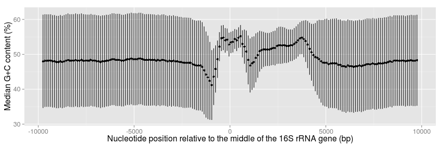

```python
%%R -w 12 -h 4 -u in

p = ggplot(tbl.sum, aes(x=pos_local, y=median, ymin=ymin, ymax=ymax))+
        geom_pointrange() +
        labs(y='Median G+C content (%)', x='Nucleotide position relative to the middle of the 16S rRNA gene (bp)') +
        theme(
            text = element_text(size=16),
            axis.title.y = element_text(vjust=0.4)
            )

#ggsave(p,
#       file="~/notebook/deltaGC_notes/data/amplicon/140331_allBac/amp454-L215-N1k/GC_dist/prokBac-CompRep_16S_GC-byWindow_sd.pdf",
#        width=12, height=4, units='in')
print(p)
#dev.off()
xxx=1
```

### Example taxa

- Clostridium ljungdahlii DSM 13528, complete genome
- Escherichia coli APEC O78, complete genome
- Streptomyces griseus subsp. griseus NBRC 13350 DNA, complete genome
- Lactobacillus gasseri ATCC 33323, complete genome

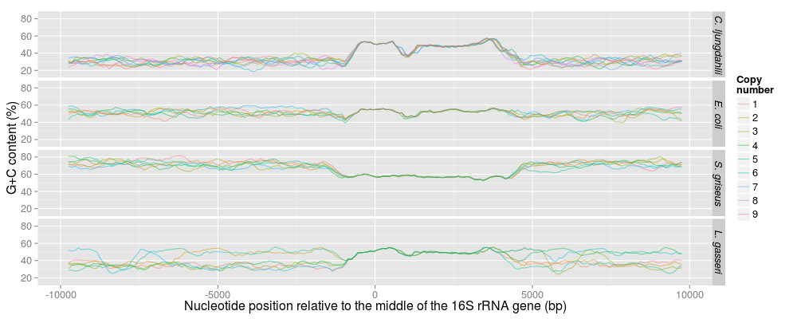

```python
%%R -w 1000 -h 400
# parsing out select taxa to show GC content
tbl$genome = gsub("\n", " ", tbl$genome)

## unique list of genomes
u.genome = unique(tbl$genome)

## selecting examples
examples = c(
"CP001666 Clostridium ljungdahlii DSM 13528, complete genome.",
"CP004009 Escherichia coli APEC O78, complete genome.",
"AP009493 Streptomyces griseus subsp. griseus NBRC 13350 DNA, complete genome.",
"CP000413 Lactobacillus gasseri ATCC 33323, complete genome."
)
q = paste(examples, collapse="|");
tbl.p = tbl[grep(q, tbl$genome),]
tbl.p$read_num = as.character(tbl.p$read_num)


## editing names
new.names = c(
"C. ljungdahlii",
"E. coli",
"S. griseus",
"L. gasseri"
)

for(i in 1:length(examples)){
    tbl.p$genome = gsub(examples[i], new.names[i], tbl.p$genome)
    }

## ordering
tbl.p$genome = factor(tbl.p$genome, levels=new.names)

## plotting
p.ex = ggplot(tbl.p, aes(pos_local, GC, group=readID, color=read_num)) +
        geom_line(alpha=0.5) +
        facet_grid(genome ~ .) +
        scale_y_continuous(limits=c(15,85)) +
        scale_color_discrete(name='Copy\nnumber') +
        labs(y='G+C content (%)', x='Nucleotide position relative to the middle of the 16S rRNA gene (bp)') +
        theme(
            text = element_text(size=16),
            strip.text = element_text(face="italic"),
            axis.title.y = element_text(vjust=0.4)
            )
#ggsave(p.ex,
#       file="~/notebook/deltaGC_notes/data/amplicon/140331_allBac/amp454-L215-N1k/GC_dist/prokBac-CompRep_16S_GC-byWindow_Ex.pdf",
#        width=12, height=5, units='in')
print(p.ex)
```

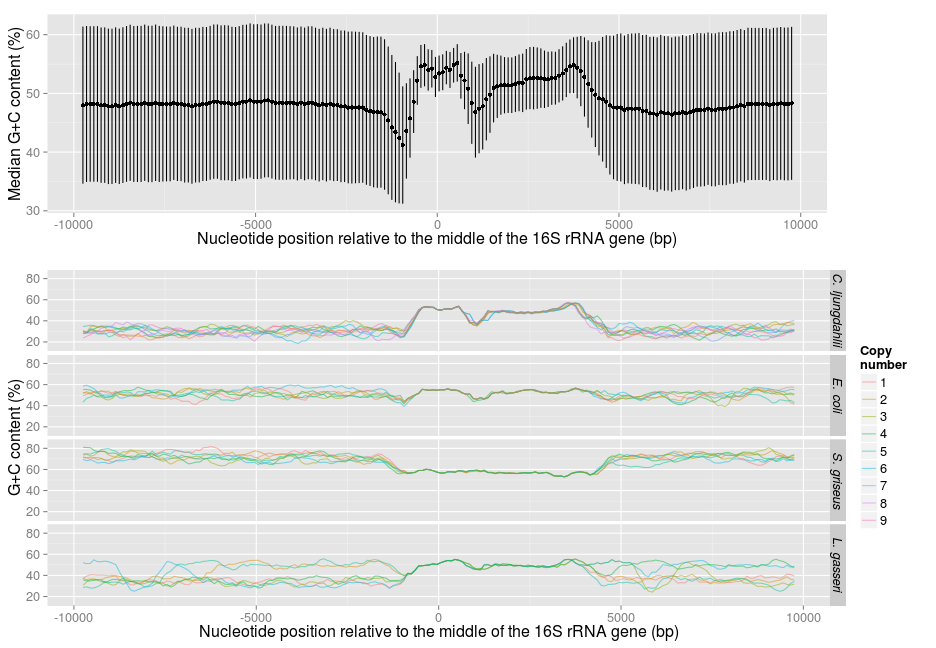

```python
%%R -w 13 -h 9 -u in
# combining the plots
blankPanel = grid.rect(gp=gpar(col="white"))

## making plot
#tiff(file="~/notebook/deltaGC_notes/data/amplicon/140331_allBac/amp454-L215-N1k/GC_dist/prokBac-CompRep_16S_GC-byWindow_comb.tiff",
#        width=13, height=9, units='in', res=300)
#svg(file="~/notebook/deltaGC_notes/data/amplicon/140331_allBac/amp454-L215-N1k/GC_dist/prokBac-CompRep_16S_GC-byWindow_comb.svg",
#        width=13, height=9)
grid.arrange(arrangeGrob(p, blankPanel, ncol=2, widths=c(8.9,1)), p.ex, ncol=1, heights=c(1.3,2))
#dev.off()
xxx=1
```

### Calculating GC stats for ssu, lsu, tsu, and 16S-23S-ITS region

@ system76-server:~/notebook/deltaGC_notes/data/amplicon/140411_allBac/amp454-L215-N1k/140428_rrn_GCstats

**Getting all rnammer ssu hits**

```
egrep -v "^#" /var/seq_data/ncbi_db/genome/rnammer/bacteria_ssu/*gff | perl -pe 's/:/\t/' | grep -f <(grep ">" ../amp454-L215-N1k_reads.fa | perl -pe 's/.+description="|"//g;s/$/_rrn.gff/' | sort -u) > rnammer_bac-amp454.txt
```

**Calculating stats**

```
$ rnammer_rrn_GCstats.pl -g <(perl -pe 's/_rrn.gff//' rnammer_bac-amp454.txt) -f /var/seq_data/ncbi_db/genome/prok-bac-genomes/ --debug | less

gene    min    mean    median    max    stdev
5s_rRNA    41.667    57.83    57.522    71.552    5.078
23s_rRNA    22.421    52.703    52.508    66.031    3.029
ITS    9.375    44.256    44.136    73.42    8.816
16s_rRNA    35.178    54.704    54.525    65.911    2.863
```

# Archaea

## GC_dist on the NCBI archaeal genome dataset

- using genome & read files from notebook 'deltaGC_arc_amp_sims'

**Filtering reads**

- just need 1 amplicon from each 16S gene copy in each genome

@ system76-server:~/notebook/deltaGC_notes/data/amplicon/140403_allArc/amp454-L215-N1k/GC_dist

```
grinder_readFilter.pl -r ../amp454-L215-N1k_reads.fa > amp454-L215-N1k_reads_filt.fa
    * overlap window = 100bp

Number of reads pre-filtering: 101000
Number remaining post-filtering: 175
```

**Getting GC distribution (sliding window)**

@ system76-server:~/notebook/deltaGC_notes/data/amplicon/140403_allArc/amp454-L215-N1k/GC_dist

```
GC_dist.pl -r amp454-L215-N1k_reads_filt.fa -g ../../prokArc-CompRep.fna -a -t 12 > prokArc-CompRep_16S_GC-byWindow.txt
```

## Making plots of GC distribution

```python
%load_ext rmagic
```

```python
%%R
require(ggplot2)
require(data.table)
```

```python
%%R
tbl = fread("~/notebook/deltaGC_notes/data/amplicon/140403_allArc/amp454-L215-N1k/GC_dist/prokArc-CompRep_16S_GC-byWindow.txt",
            header=T)

## setting position around center
tbl[,pos_local:=(pos_local - 10000)]
```

```
                                                                    genome
    1: CP006885 Haloarcula hispanica N601 chromosome 2, complete sequence.
    2: CP006885 Haloarcula hispanica N601 chromosome 2, complete sequence.
    3: CP006885 Haloarcula hispanica N601 chromosome 2, complete sequence.
    4: CP006885 Haloarcula hispanica N601 chromosome 2, complete sequence.
    5: CP006885 Haloarcula hispanica N601 chromosome 2, complete sequence.
   ---
34220:            CP003377 Natronobacterium gregoryi SP2, complete genome.
34221:            CP003377 Natronobacterium gregoryi SP2, complete genome.
34222:            CP003377 Natronobacterium gregoryi SP2, complete genome.
34223:            CP003377 Natronobacterium gregoryi SP2, complete genome.
34224:            CP003377 Natronobacterium gregoryi SP2, complete genome.
           scaf                  readID read_num pos_local pos_global   GC
    1: CP006885 CP006885__CP006885__307        1     -9750        251 47.6
    2: CP006885 CP006885__CP006885__307        1     -9650        451 47.8
```

[output cut: 21 more lines]

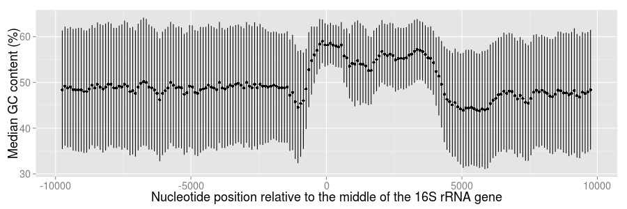

```python
%%R -w 900 -h 300
# plotting interquartile ranges of values at each relative position
## median & stdev by pos_local
tbl.median = tbl[, median(GC), by="pos_local"]
setkey(tbl.median, pos_local)
tbl.stdev = tbl[, sd(GC), by="pos_local"]
setkey(tbl.stdev, pos_local)

# merging
tbl.sum = merge(tbl.median, tbl.stdev)
colnames(tbl.sum) = c('pos_local', 'median', 'stdev')

# ymin & ymax
tbl.sum$ymin = tbl.sum$median - tbl.sum$stdev
tbl.sum$ymax = tbl.sum$median + tbl.sum$stdev

# plotting
p = ggplot(tbl.sum, aes(x=pos_local, y=median, ymin=ymin, ymax=ymax))+
        geom_pointrange() +
        labs(y='Median GC content (%)', x='Nucleotide position relative to the middle of the 16S rRNA gene') +
        theme( text = element_text(size=18))

ggsave(file="~/notebook/deltaGC_notes/data/amplicon/140403_allArc/amp454-L215-N1k/GC_dist/prokArc-CompRep_16S_GC-byWindow_sd.tiff",
        width=12, height=4, units='in', dpi=300)
print(p)
xxx=1
```

### Calculating GC stats for ssu, lsu, tsu, and 16S-23S-ITS region

**Getting all rnammer ssu hits**

```
egrep -v "^#" /var/seq_data/ncbi_db/genome/rnammer/archaea_ssu/*gff | perl -pe 's/:/\t/' | grep -f <(grep ">" ../amp454-L215-N1k_reads.fa | perl -pe 's/.+description="|"//g;s/$/_rrn.gff/' | sort -u) > rnammer_bac-amp454.txt
```

**Calculating GC content stats**

@ system76-server:~/notebook/deltaGC_notes/data/amplicon/140403_allArc/amp454-L215-N1k/140428_rrn_GCstats

[output not shown]